# TP Estadística Descriptiva

Autores: Tomas Santucci y Fernando Silva

2022-04-27

###### Introduccion:

Este informe esta destinado a mostrar estadisticamente el uso de las ecobicis provenientes de la Ciudad Autonoma de Buenos Aires. Desde el mismo se podran observar datos Univariados y Bivariados para tener una mayor apreciación de la utilidad de las mismas.

## Análisis univariado

### Variable género (Grafico de Sectores)

Es una variable cualitativa cuyos valores posibles son: Masculino, Femenino y Otro

Representa el género de los usuarios que han utilizado las ecobici.

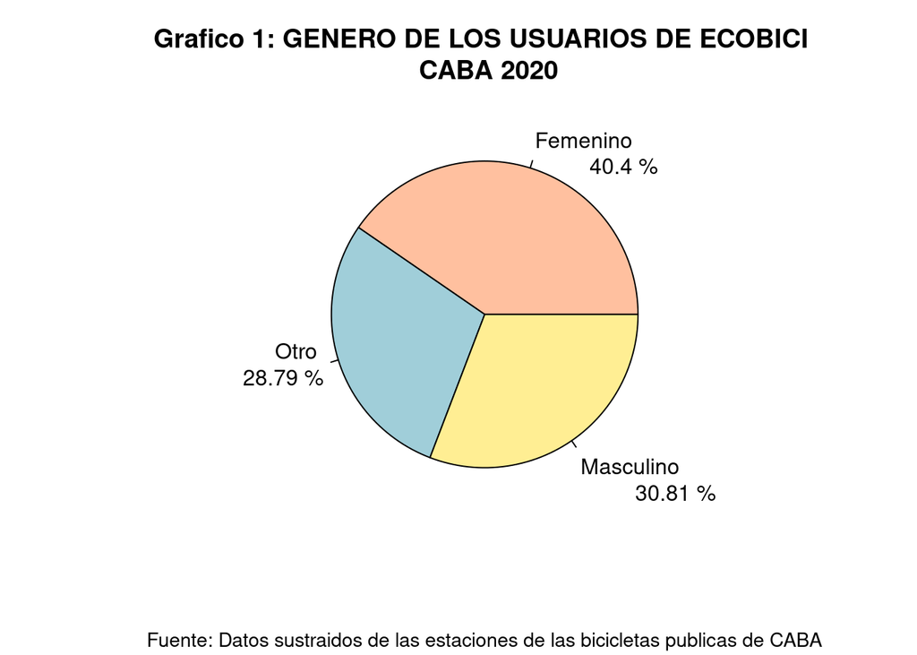

Medida de interés:

Moda : Mujeres

### Variable edad (Histograma)

Es una variable cuantitativa continua cuyos valores están entre 15 y 72. Representa la edad de los usuarios de ecobici.

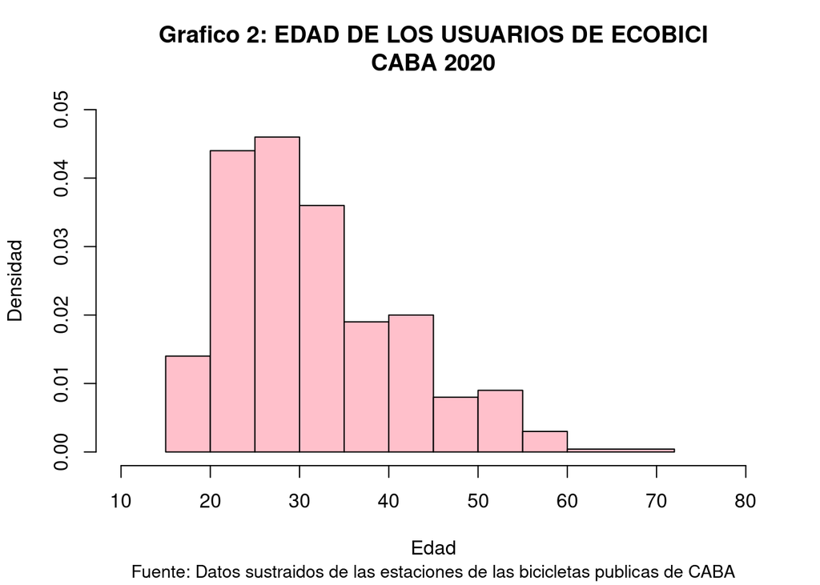

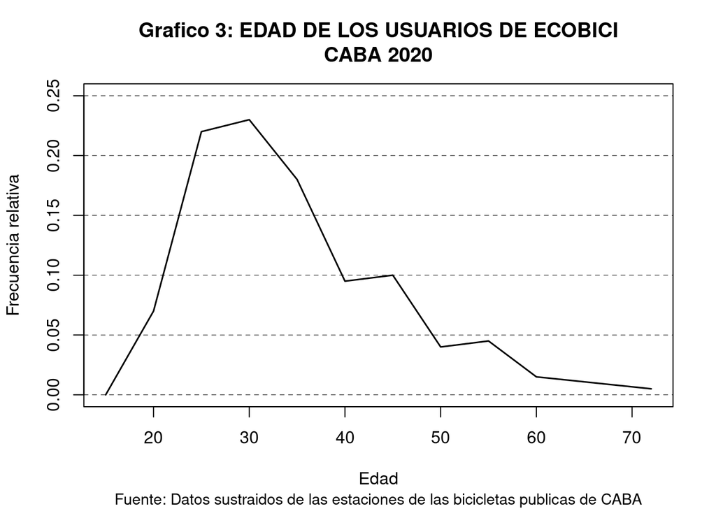

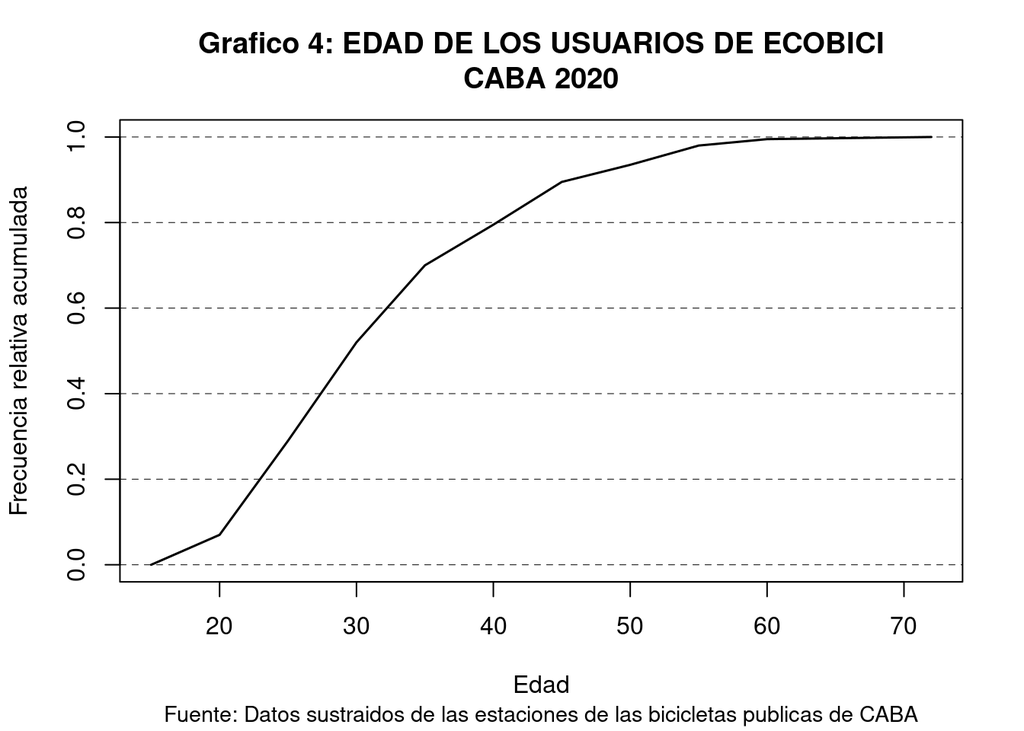

En el Grafico 3, se puede ver claramente el aumento del uso de las ecobici, de manera creciente entre los usuarios cuyas edades van desde 20 a 30 años y luego va decreciendo a medida que aumenta la edad de los mismos. En otras palabras los usuarios de entre 20 a 35 años utilizan más el servicio, que aquellos usuarios mayores.

### Variable dias (Grafico de Barras)

Es una variable cualitativa cuyos valores posibles. Cuyos valores posibles son Lunes, Martes, Miércoles, Jueves, Viernes, Sábado y Domingo. Representa los días en que se efectuaron los viajes.

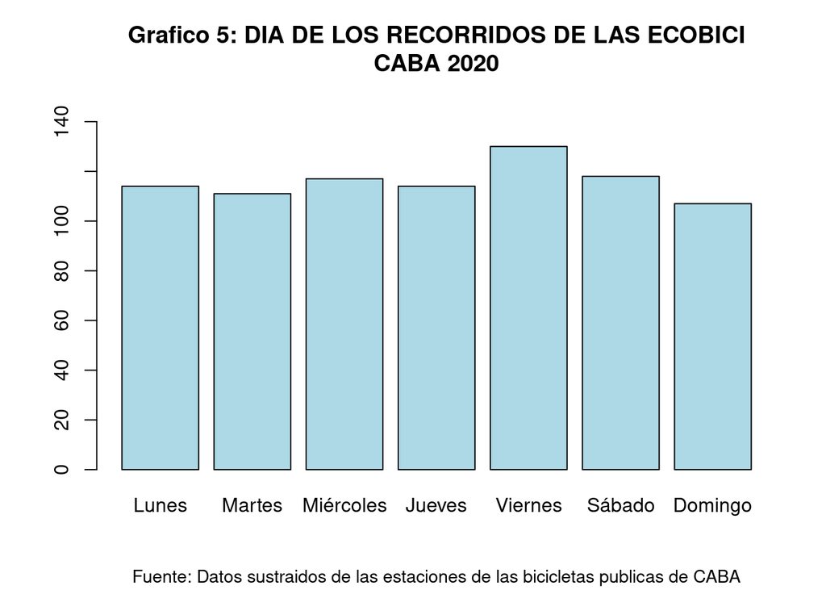

En el Grafico 5 se puede observar que la mayor cantidad de viajes se efectuan los dias viernes. Se puede suponer que ese dia se efectuan dicha cantidad de viajes, debido a que es el ultimo dia laboral de la semana y la mayoria de los usuarios obta por este servicio para poder regresar a sus casas a tiempo.

Medidas de interés:

Moda: Viernes

### Variable estación de origen (Tabla de Frecuencias mas Grafico de Barras)

Es una variable cualitativa. Representa a las estaciones donde se originaron los viajes.

Se representan las estaciones más utilizadas, debido a la gran cantidad de estaciones de origen.

Tabla de frecuencias

| Estación | Frecuencia absoluta | Frecuencia relativa | Frecuencia absoluta acumulada | Frecuencia relativa acumulada |
| --- | --- | --- | --- | --- |
| Cevallos, Virrey& Yrigoyen, Hipolito Av. | 23 | 0.0284 | 23 | 0.0284 |
| 137 Aranguren, Juan F., Dr. & Portugal | 18 | 0.0222 | 41 | 0.0506 |
| Lavalle & Acuña De Figueroa, Francisco | 18 | 0.0222 | 59 | 0.0727 |
| 3568 Estados Unidos & Boedo Av. | 16 | 0.0197 | 75 | 0.0925 |
| Vera Peñaloza, Rosario 599 & Lanteri Julieta | 16 | 0.0197 | 91 | 0.1122 |
| Peña & Azcuenaga | 15 | 0.0185 | 106 | 0.1307 |
| 1785 Espinosa | 14 | 0.0173 | 120 | 0.148 |
| Olleros Av. & Del Libertador Av. | 14 | 0.0173 | 134 | 0.1652 |
| Av. Patricias Argentinas & Estivao | 13 | 0.016 | 147 | 0.1813 |
| Guatemala 4773 | 13 | 0.016 | 160 | 0.1973 |
| 2000 Vicente Lopez | 12 | 0.0148 | 172 | 0.2121 |
| Andres Lamas&Remedios Escalada de San Martin | 12 | 0.0148 | 184 | 0.2269 |
| Avenida Juan de Garay 1050 | 12 | 0.0148 | 196 | 0.2417 |
| Juana De Ibarbourou & Av Patricias Argentinas | 12 | 0.0148 | 208 | 0.2565 |
| Villaflor, Azucena & Dealessi, Pierina | 12 | 0.0148 | 220 | 0.2713 |

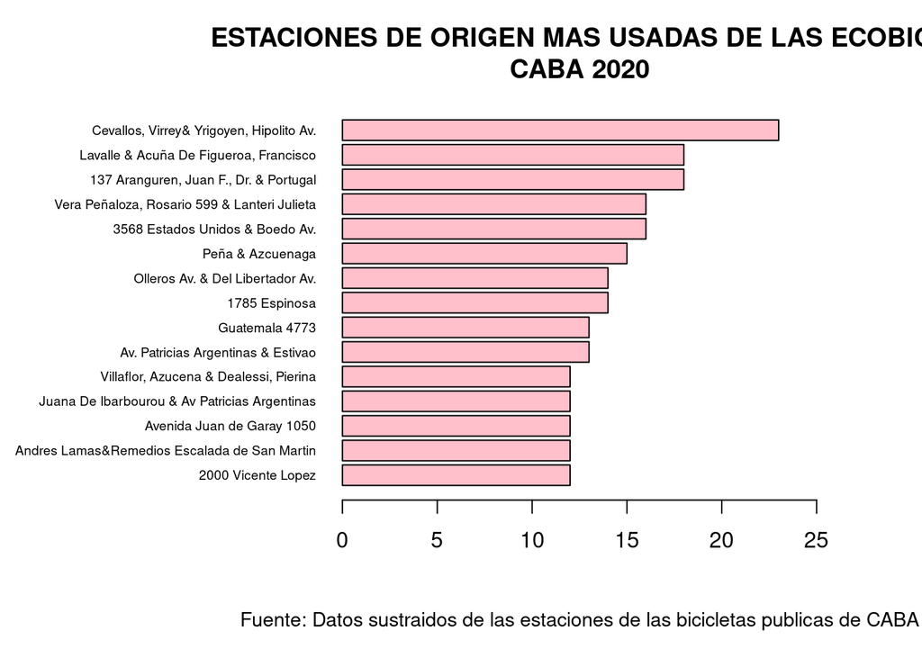

Se puede ver a partir de la tabla que alrededor del 27% de los viajes se originaron en sólo 15 de las 169 estaciones.

Medidas de interés:

Moda: Cevallos, Virrey & Yrigoyen, Hipolito Av.

### Variable estación de Destino (Tabla de Frecuencias mas Grafico de Barras)

Es una variable cualitativa. Representa a las estaciones de destino de cadad viaje.

Se representan las estaciones más utilizadas, debido a la gran cantidad de estaciones de destino.

Tabla de frecuencias

| Estación | Frecuencia absoluta | Frecuencia relativa | Frecuencia absoluta acumulada | Frecuencia relativa acumulada |
| --- | --- | --- | --- | --- |
| Lavalle & Acuña De Figueroa, Francisco | 25 | 0.0308 | 25 | 0.0308 |
| Fitz Roy & Gorriti | 20 | 0.0247 | 45 | 0.0555 |
| Peña & Azcuenaga | 16 | 0.0197 | 61 | 0.0752 |
| Cevallos, Virrey& Yrigoyen, Hipolito Av. | 15 | 0.0185 | 76 | 0.0937 |
| Vera Peñaloza, Rosario 599 & Lanteri Julieta | 14 | 0.0173 | 90 | 0.111 |
| 1540 Garcia, Juan Agustin | 13 | 0.016 | 103 | 0.127 |
| 3822 Guemes | 13 | 0.016 | 116 | 0.143 |
| Juana De Ibarbourou & Av Patricias Argentinas | 13 | 0.016 | 129 | 0.1591 |
| 2080 Austria | 12 | 0.0148 | 141 | 0.1739 |
| 2519 Conesa | 12 | 0.0148 | 153 | 0.1887 |
| Armenia 1525 y Gorriti | 12 | 0.0148 | 165 | 0.2035 |
| Avenida Juan de Garay 1050 | 12 | 0.0148 | 177 | 0.2182 |
| Avenida Rivadavia y Fray Cayetano | 12 | 0.0148 | 189 | 0.233 |
| Dr Tomas Manuel De Anchorena & Jose A. Cabrera | 12 | 0.0148 | 201 | 0.2478 |
| 169 Peru & Roca, Julio A., Presidente Diagonal Sur Av. | 11 | 0.0136 | 212 | 0.2614 |

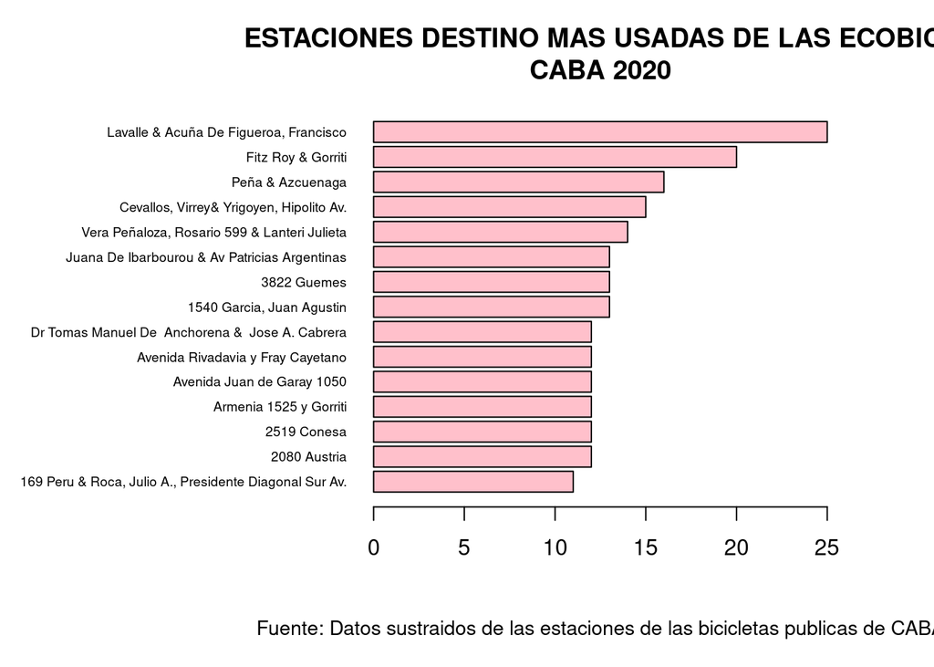

Se puede ver que a partir de la tabla, alrededor de 26% de los viajes tuvieron como destino solo 15 de las 171 estaciones.

Medidas de interés:

Moda: Lavalle & Acuña De Figueroa, Francisco

## Variable distancia

Es una variable cuantitativa continua. Sus valores están entre 0 y 20 km. Cualquier apreciación mayor a 20 km es considerada un error de sistema o humano y por lo tanto no es tenida en cuenta en el análisis.

```
##    Min. 1st Qu.  Median    Mean 3rd Qu.    Max.
##  0.7046  2.8305  4.3636  4.9697  6.2129 18.3057
```

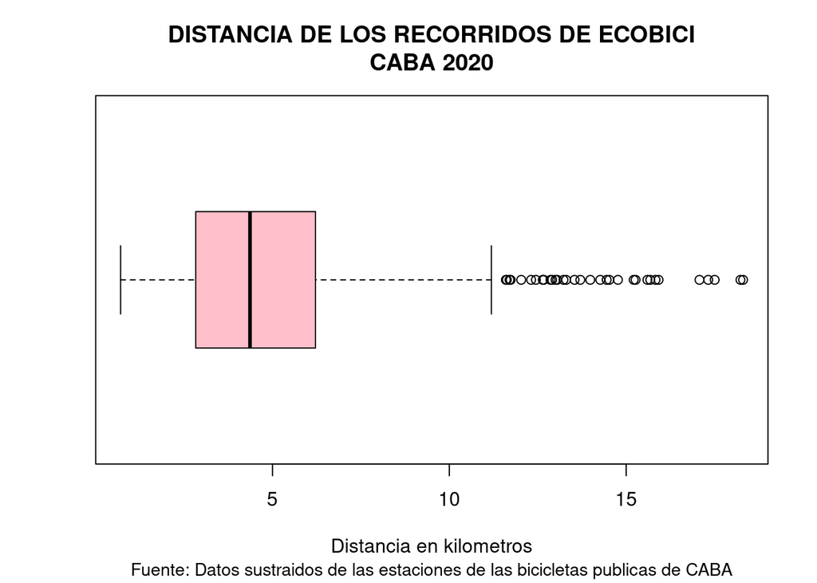

En el boxplot se puede ver que:

El mínimo recorrido fue 700 metros y el máximo fue 18.30 km

El 25% recorrió menos de 2.83 km.

El 50% recorrió menos de 4.36 km.

El 75% recorrió menos de 6.21 km.

Medidas de interés:

Mínimo: 0.70 km  
Mediana: 4.36  
Media: 4.96  
Maximo: 18.30 (outlier)

### Variable duración

```
##    Min. 1st Qu.  Median    Mean 3rd Qu.    Max.
##    4.05   13.59   21.73   26.82   31.21  473.20
```

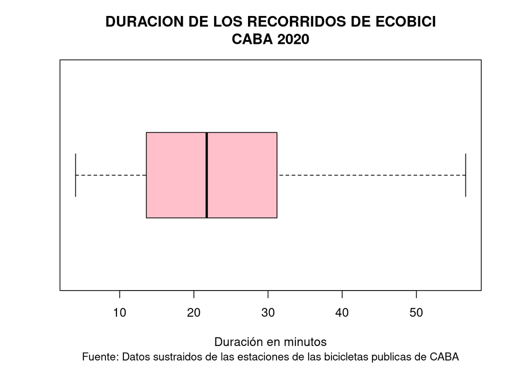

A partir del Boxplot se puede ver que:

El 25% de los usuarios utilizo el servicio menos de 13.59 min

El 50% de los usuarios utilizo el servicio menos de 21.73 min

El 75% de los usuarios utilizo el servicio menos de 31.21 min

Medidas de interés:

Minimo: 4.05 min Mediana: 21.73 min Media: 26.82 min Maximo: 473.20 min (outlider)

### Variable cantidad de viajes por usuario

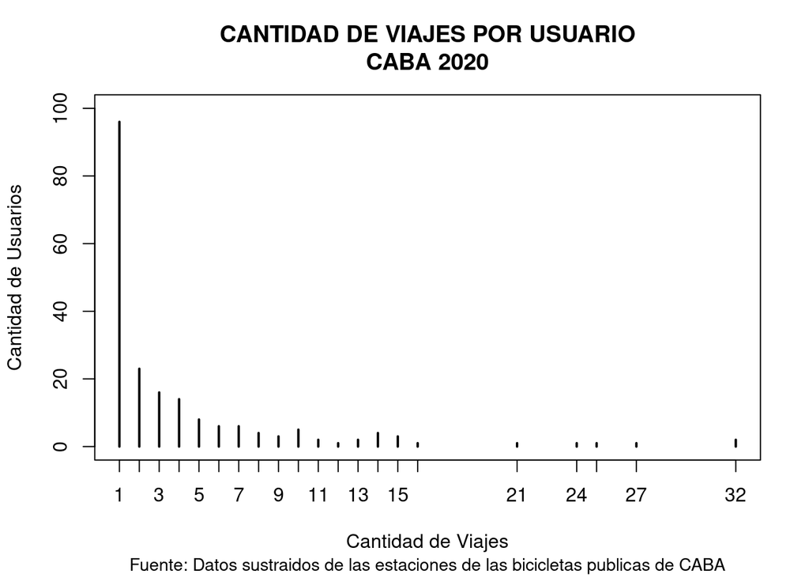

A partir del grafico de bastones se puede ver que:

96 Usuarios realizaron un solo viaje

solamente 2 usuarios realizaron 32 viajes

# Análisis bivariado

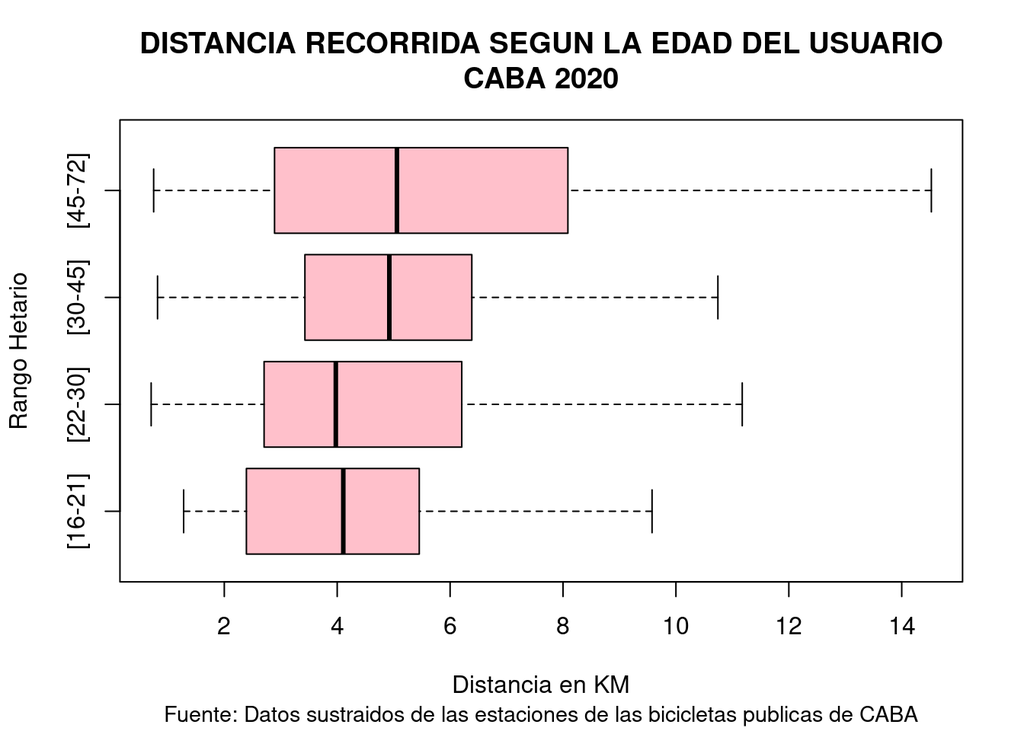